# Statistical Computing

School of Economics and Management  
Beihang University  
http://yanfei.site

## Primary R Functions

The primary R functions for dealing with text data are

- `grep()`, `grepl()`: These functions search for matches of a regular pattern in a character vector. `grep()` returns the indices into the character vector that contain a match or the specific strings that happen to have the match. `grepl()` returns a `TRUE`/`FALSE` vector indicating which elements of the character vector contain a match.
- `regexpr()`, `gregexpr()`: Search a character vector for pattern matches and return the indices of the string where the match begins and the length of the match.
- `sub()`, `gsub()`: Search a character vector for pattern matches and replace that match with another string.
- `substr()`: Extract substrings in a character vector.
- `regexec()`: This function searches a character vector for a pattern, much like `regexpr()`, but it will additionally return the locations of any parenthesized sub-expressions. Probably easier to explain through demonstration.

## Text data

We will use a running example using data from homicides in Baltimore City. You can get the file from https://yanfei.site/docs/sc/data/homicides.txt. Original data is from https://homicides.news.baltimoresun.com.

```r
homicides <- readLines("../data/homicides.txt")
## Total number of events recorded
length(homicides)
```

```
## [1] 1571
```

```r
homicides[1]
```

```
## [1] "39.311024, -76.674227, iconHomicideShooting, 'p2', '<dl><dt>Leon Nelson</dt><dd class=\"address\">3400 Clifton Ave.<br />Baltimore, MD 21216</dd><dd>black male, 17 years old</dd><dd>Found on January 1, 2007</dd><dd>Victim died at Shock Trauma</dd><dd>Cause: shooting</dd></dl>'"
```

```r
homicides[1000]
```

```
## [1] "39.33626300000, -76.55553990000, icon_homicide_shooting, 'p1200', '<dl><dt><a href=\"http://essentials.baltimoresun.com/micro_sun/homicides/victim/1200/davon-diggs\">Davon Diggs</a></dt><dd class=\"address\">4100 Parkwood Ave<br />Baltimore, MD 21206</dd><dd>Race: Black<br />Gender: male<br …
```

We have the latitude and longitude of where the victim was found; then there's the street address; the age, race, and gender of the victim; the date on which the victim was found; in which hospital the victim ultimately died; the cause of death.

## `grep()`

Suppose we wanted to identify the records for all the victims of shootings (as opposed to other causes)? How could we do that?

Here I use `grep()` to match the literal `iconHomicideShooting` into the character vector of homicides.

```r
g <- grep("iconHomicideShooting", homicides)
length(g)
```

```
## [1] 228
```

Using this approach I get 228 shooting deaths. However, I notice that for some of the entries, the indicator for the homicide "flag" is noted as `icon_homicide_shooting`. It's not uncommon over time for web site maintainers to change the names of files or update files. What happens if we now `grep()` on both icon names using the `|` operator?

```r
g <- grep("iconHomicideShooting|icon_homicide_shooting", homicides)
length(g)
```

```
## [1] 1263
```

## `grep()`

Another possible way to do this is to `grep()` on the cause of death field, which seems to have the format `Cause: shooting`. We can `grep()` on this literally and get

```r
g <- grep("Cause: shooting", homicides)
length(g)
```

```
## [1] 228
```

Notice that we seem to be undercounting again. This is because for some of the entries, the word "shooting" uses a captial "S" while other entries use a lower case "s". We can handle this variation by using a character class in our regular expression.

```r
g <- grep("Cause: [Ss]hooting", homicides)
length(g)
```

```
## [1] 1263
```

## `grepl()`

The function `grepl()` works much like `grep()` except that it differs in its return value. `grepl()` returns a logical vector indicating which element of a character vector contains the match. For example, suppose we want to know which states in the United States begin with word "New".

```r
g <- grepl("^New", state.name)
g
```

```
##  [1] FALSE FALSE FALSE FALSE FALSE FALSE FALSE FALSE FALSE
## [10] FALSE FALSE FALSE FALSE FALSE FALSE FALSE FALSE FALSE
## [19] FALSE FALSE FALSE FALSE FALSE FALSE FALSE FALSE FALSE
## [28] FALSE  TRUE  TRUE  TRUE  TRUE FALSE FALSE FALSE FALSE
## [37] FALSE FALSE FALSE FALSE FALSE FALSE FALSE FALSE FALSE
## [46] FALSE FALSE FALSE FALSE FALSE
```

```r
state.name[g]
```

```
## [1] "New Hampshire" "New Jersey"    "New Mexico"
## [4] "New York"
```

Here, we can see that `grepl()` returns a logical vector that can be used to subset the original `state.name` vector.

## `regexpr()`

- Both the `grep()` and the `grepl()` functions have some limitations - they don't tell you exactly where the match occurs or what the match is for a more complicated regular expression.
- The `regexpr()` function gives you
  - index into each string where the match begins
  - length of the match for that string.
- `regexpr()` only gives you the *first* match of the string (reading left to right). `gregexpr()` will give you *all* of the matches in a given string if there are is more than one match.

## `regexpr()` Example

In our Baltimore City homicides dataset, we might be interested in finding the date on which each victim was found. Taking a look at the dataset

```r
homicides[1]
```

```
## [1] "39.311024, -76.674227, iconHomicideShooting, 'p2', '<dl><dt>Leon Nelson</dt><dd class=\"address\">3400 Clifton Ave.<br />Baltimore, MD 21216</dd><dd>black male, 17 years old</dd><dd>Found on January 1, 2007</dd><dd>Victim died at Shock Trauma</dd><dd>Cause: shooting</dd></dl>'"
```

it seems that we might be able to just `grep` on the word "Found". However, the word "found" may be found elsewhere in the entry, such as in this entry, where the word "found" appears in the narrative text at the end.

```r
homicides[954]
```

```
## [1] "39.30677400000, -76.59891100000, icon_homicide_shooting, 'p816', '<dl><dt><a href=\"http://essentials.baltimoresun.com/micro_sun/homicides/victim/816/kenly-wheeler\">Kenly Wheeler</a></dt><dd class=\"address\">1400 N Caroline St<br />Baltimore, MD 21213</dd><dd>Race: Black<br />Gender: male<…
```

But we can see that the date is typically preceded by "Found on" and is surrounded by `<dd></dd>` tags, so let's use the pattern `<dd>[F|f]ound(.*)</dd>` and see what it brings up.

```r
regexpr("<dd>[F|f]ound(.*)</dd>", homicides[1:10])
```

```
##  [1] 177 178 188 189 178 182 178 187 182 183
## attr(,"match.length")
##  [1] 93 86 89 90 89 84 85 84 88 84
## attr(,"index.type")
## [1] "chars"
## attr(,"useBytes")
## [1] TRUE
```

We can use the `substr()` function to extract the first match in the first string.

```r
substr(homicides[1], 177, 177 + 93 - 1)
```

```
## [1] "<dd>Found on January 1, 2007</dd><dd>Victim died at Shock Trauma</dd><dd>Cause: shooting</dd>"
```

Picked up too much information? We need to use the `?` metacharacter to make the regular expression "lazy" so that it stops at the *first* `</dd>` tag.

```r
regexpr("<dd>[F|f]ound(.*?)</dd>", homicides[1:10])
```

```
##  [1] 177 178 188 189 178 182 178 187 182 183
## attr(,"match.length")
##  [1] 33 33 33 33 33 33 33 33 33 33
## attr(,"index.type")
## [1] "chars"
## attr(,"useBytes")
## [1] TRUE
```

Now when we look at the substrings indicated by the `regexpr()` output, we get

```r
substr(homicides[1], 177, 177 + 33 - 1)
```

```
## [1] "<dd>Found on January 1, 2007</dd>"
```

Instead of using `substr()`, `regmatches()` is more handy.

```r
r <- regexpr("<dd>[F|f]ound(.*?)</dd>", homicides[1:5])
regmatches(homicides[1:5], r)
```

```
## [1] "<dd>Found on January 1, 2007</dd>"
## [2] "<dd>Found on January 2, 2007</dd>"
## [3] "<dd>Found on January 2, 2007</dd>"
## [4] "<dd>Found on January 3, 2007</dd>"
## [5] "<dd>Found on January 5, 2007</dd>"
```

## `sub()` and `gsub()`

Sometimes we need to clean things up or modify strings by matching a pattern and replacing it with something else. For example, how can we extract the date from this string?

```r
x <- substr(homicides[1], 177, 177 + 33 - 1)
x
```

```
## [1] "<dd>Found on January 1, 2007</dd>"
```

We want to strip out the stuff surrounding the "January 1, 2007" portion. We can do that by matching on the text that comes before and after it using the `|` operator and then replacing it with the empty string.

```r
sub("<dd>[F|f]ound on |</dd>", "", x)
```

```
## [1] "January 1, 2007</dd>"
```

Notice that the `sub()` function found the first match (at the beginning of the string) and replaced it and then stopped. However, there was another match at the end of the string that we also wanted to replace. To get both matches, we need the `gsub()` function.

```r
gsub("<dd>[F|f]ound on |</dd>", "", x)
```

```
## [1] "January 1, 2007"
```

The `sub()` and `gsub()` functions can take vector arguments so we don't have to process each string one by one.

```r
r <- regexpr("<dd>[F|f]ound(.*?)</dd>", homicides[1:5])
m <- regmatches(homicides[1:5], r)
m
```

```
## [1] "<dd>Found on January 1, 2007</dd>"
## [2] "<dd>Found on January 2, 2007</dd>"
## [3] "<dd>Found on January 2, 2007</dd>"
## [4] "<dd>Found on January 3, 2007</dd>"
## [5] "<dd>Found on January 5, 2007</dd>"
```

```r
d <- gsub("<dd>[F|f]ound on |</dd>", "", m)
## Nice and clean
d
```

```
## [1] "January 1, 2007" "January 2, 2007" "January 2, 2007"
## [4] "January 3, 2007" "January 5, 2007"
```

Finally, it may be useful to convert these strings to the `Date` class so that we can do some date-related computations.

```r
as.Date(d, "%B %d, %Y")
```

```
## [1] "2007-01-01" "2007-01-02" "2007-01-02" "2007-01-03"
## [5] "2007-01-05"
```

## `regexec()`

The `regexec()` function works like `regexpr()` except it gives you the indices for parenthesized sub-expressions. For example, take a look at the following expression.

```r
regexec("<dd>[F|f]ound on (.*?)</dd>", homicides[1])
```

```
## [[1]]
## [1] 177 190
## attr(,"match.length")
## [1] 33 15
## attr(,"index.type")
## [1] "chars"
## attr(,"useBytes")
## [1] TRUE
```

Here's the overall expression match.

```r
substr(homicides[1], 177, 177 + 33 - 1)
```

```
## [1] "<dd>Found on January 1, 2007</dd>"
```

And here's the parenthesized sub-expression.

```r
substr(homicides[1], 190, 190 + 15 - 1)
```

```
## [1] "January 1, 2007"
```

All this can be done much more easily with the `regmatches()` function.

```r
r <- regexec("<dd>[F|f]ound on (.*?)</dd>", homicides[1:2])
regmatches(homicides[1:2], r)
```

```
## [[1]]
## [1] "<dd>Found on January 1, 2007</dd>"
## [2] "January 1, 2007"
##
## [[2]]
## [1] "<dd>Found on January 2, 2007</dd>"
## [2] "January 2, 2007"
```

## `regexec()`

As an example, we can make a plot of monthly homicide counts. First we need a regular expression to capture the dates.

```r
r <- regexec("<dd>[F|f]ound on (.*?)</dd>", homicides)
m <- regmatches(homicides, r)
```

Then we can loop through the list returned by `regmatches()` and extract the second element of each (the parenthesized sub-expression).

```r
dates <- sapply(m, function(x) x[2])
```

Finally, we can convert the date strings into the `Date` class and make a histogram of the counts.

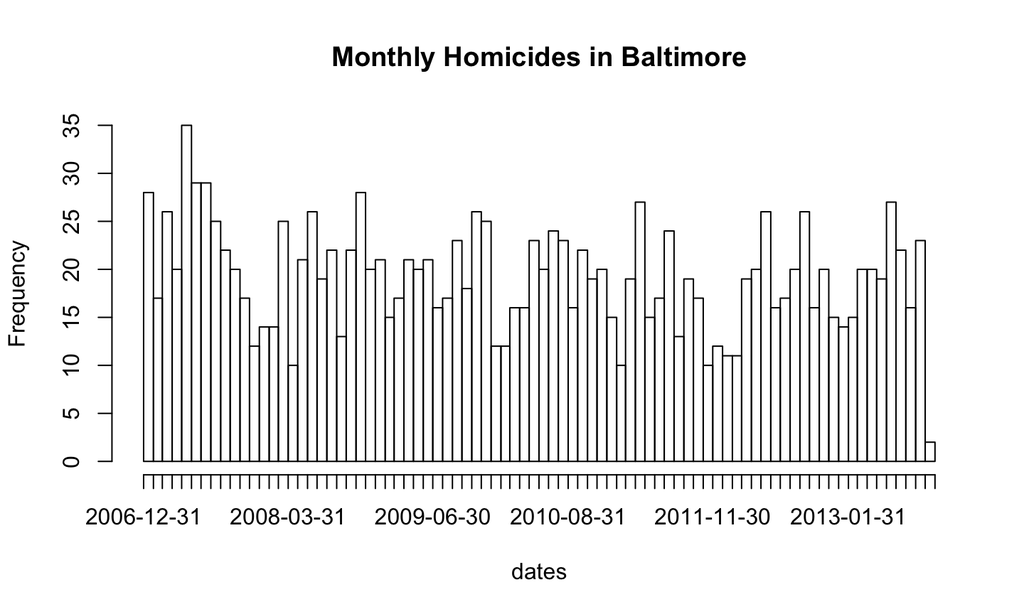

```r
invisible(dates <- as.Date(dates, "%B %d, %Y"))
hist(dates, "month", freq = TRUE, main = "Monthly Homicides in Baltimore")
```

We can see from the picture that homicides do not occur uniformly throughout the year and appear to have some seasonality to them.

## Summary

The primary R functions for dealing with regular expressions are

- `grep()`, `grepl()`: Search for matches of a regular expression/pattern in a character vector
- `regexpr()`, `gregexpr(): Search a character vector for regular expression matches and return the indices where the match begins; useful in conjunction with`regmatches()`
- `sub()`, `gsub()`: Search a character vector for regular expression matches and replace that match with another string
- `regexec()`: Gives you indices of parethensized sub-expressions.

## Lab Session 3

In this lab, you will play around text processing using R.

1. Load text from the https://yanfei.site/docs/dpsa/BABAnews.txt and print it on screen. Text file contains some of the news of Alibaba.
2. How many paragraphs are there in the article?
3. Trim leading whitespaces of each paragraph (try `??trim`).
4. How many characters are there in the article?
5. Collapse paragraphs into one and display it on the screen (un-list it).
6. Does the text contain word '技术架构'?
7. Split the article into sentences (by periods).
8. Replace '双11' with '双十一'.

## References

Chapter 19 of the book "R programming for data science".